# Homework 8

Katie Bardsley

3/31/2021

### Creating Fake Data Sets to Explore Hypothesis

#### 1. Budbreak data set

Here I will be focusing on bud flush phenology in poplar, thinking about patterns similar to those being studied in the Keller Lab currently. In a common garden, you might expect samples taken from colder climates to break bud earlier than those from warmer climates as they have a shorter growing season and need to take advantage of all the warm days they can get.

#### 2. Setting initial parameters

```r
# cold source climate
n_cold <- 500
mean_cold <- 105
var_cold <- 75

# warm source climate
n_warm <- 500
mean_warm <- 115
var_warm <- 75
```

The variances were based on the fact that we normally start monitoring bud break in mid March and finish in early June. I estimated the number of Julian days during the period of time where bud flush is monitored and used that to predict the variance of the two groups. The means were also estimated based on the same time period, as I know that we commonly see the plants from colder source climates break bud slightly earlier. This information comes from my experience monitoring bud break as well as conversations I have had with other lab members.

#### 3. Generating random data and setting it up in a data frame

```r
###################################
# FUNCTION: RandomBudbreakData
# description: generate random budbreak data and organize in data frame
# inputs: n, mean, and variance for each treatement
# outputs: dataframe
# ---------------------------------
RandomBudbreakData <- function(n_cold, mean_cold, var_cold, n_warm, mean_warm, var_warm){
  data_cold <- rnorm(n=n_cold, mean=mean_cold, sd=sqrt(var_cold))
  data_warm <- rnorm(n=n_warm, mean=mean_warm, sd=sqrt(var_warm))

# combine into one big data frame
  cold <- data.frame(1:n_cold, data_cold, rep("cold", n_cold))
  colnames(cold) <- c("ID", "BudBreakDay","Climate")
  warm <- data.frame((n_cold+1):(n_cold+n_warm), data_warm, rep("warm", n_cold))
  colnames(warm) <- c("ID", "BudBreakDay","Climate")
  budbreak_data <- rbind(cold, warm)
  return(budbreak_data)
} # end of RandomBudbreakData

###################################

data <- RandomBudbreakData(n_cold, mean_cold, var_cold, n_warm, mean_warm, var_warm)
```

#### 4. Creating anova model and plotting data

```r
mod <- aov(BudBreakDay ~ Climate, data=data)
summary(mod)
```

```
##              Df Sum Sq Mean Sq F value Pr(>F)
## Climate       1  25451   25451     341 <2e-16 ***
## Residuals   998  74487      75
## ---
## Signif. codes:  0 '***' 0.001 '**' 0.01 '*' 0.05 '.' 0.1 ' ' 1
```

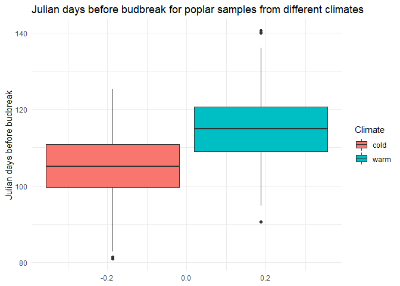

```r
ggplot(data=data, mapping=aes(y=BudBreakDay, fill=Climate)) + geom_boxplot() +
  labs(title="Julian days before budbreak for poplar samples from different climates",
       y="Julian days before budbreak") +
  theme_minimal()
```

#### 5. Running again, this time with a different set of random numbers

Repeat with same parameters and different sets of random numbers.

```r
data <- RandomBudbreakData(n_cold, mean_cold, var_cold, n_warm, mean_warm, var_warm)

mod <- aov(BudBreakDay ~ Climate, data=data)
summary(mod)
```

```
##              Df Sum Sq Mean Sq F value Pr(>F)
## Climate       1  24120   24120   329.4 <2e-16 ***
## Residuals   998  73079      73
## ---
## Signif. codes:  0 '***' 0.001 '**' 0.01 '*' 0.05 '.' 0.1 ' ' 1
```

#### 6. Changing the means for the two groups

Make the mean bud break at day 110 instead of 105 for the cold source climate so that there is less of a difference between the two groups.

```r
# cold source climate
mean_cold <- 110

# warm source climate
mean_warm <- 115

data <- RandomBudbreakData(n_cold, mean_cold, var_cold, n_warm, mean_warm, var_warm)

mod <- aov(BudBreakDay ~ Climate, data=data)
summary(mod)
```

```
##              Df Sum Sq Mean Sq F value Pr(>F)
## Climate       1   8102    8102   115.9 <2e-16 ***
## Residuals   998  69749      70
## ---
## Signif. codes:  0 '***' 0.001 '**' 0.01 '*' 0.05 '.' 0.1 ' ' 1
```

We still see significance, so bring it up to 112 for the mean bud break in the cold climate and down 113 for the warm climate.

```r
# cold source climate
mean_cold <- 112

# warm source climate
mean_warm <- 113

data <- RandomBudbreakData(n_cold, mean_cold, var_cold, n_warm, mean_warm, var_warm)

mod <- aov(BudBreakDay ~ Climate, data=data)
summary(mod)
```

```
##              Df Sum Sq Mean Sq F value  Pr(>F)
## Climate       1    617   617.4   7.897 0.00505 **
## Residuals   998  78022    78.2
## ---
## Signif. codes:  0 '***' 0.001 '**' 0.01 '*' 0.05 '.' 0.1 ' ' 1
```

#### 7. Changing the sample sizes

Play with different sample sizes

```r
# cold source climate
mean_cold <- 105
var_cold <- 75

# warm source climate
mean_warm <- 115
var_warm <- 75

# try playing with different sample sizes
sample_sizes <- c(10, 20, 30, 40, 50, 100, 200, 400, 500, 1000)
mean <- rep(999, length(sample_sizes))
count <- 1

for (n in sample_sizes){
  n_warm <- n/2
  n_cold <- n/2
  pval <- rep(999, 100)
  for (i in 1:100){
    data <- RandomBudbreakData(n_cold, mean_cold, var_cold, n_warm, mean_warm, var_warm)
    mod <- aov(BudBreakDay ~ Climate, data=data)
    summary<- summary(mod)
    pval[i] <- summary[[1]]$`Pr(>F)`[1]  # save p-value
  }
  mean[count] <- signif(mean(pval), digits=3)
  count <- count + 1

}
means <- data.frame(sample_sizes/2, mean)
colnames(means) <- c("Number of samples in each treatment",
                     "Mean p-value across 100 iterations")
print(means)
```

```
##    Number of samples in each treatment Mean p-value across 100 iterations
## 1                                    5                           1.48e-01
## 2                                   10                           6.11e-02
## 3                                   15                           1.62e-02
## 4                                   20                           1.02e-02
## 5                                   25                           3.80e-03
## 6                                   50                           5.46e-05
## 7                                  100                           1.53e-09
## 8                                  200                           3.78e-21
## 9                                  250                           4.22e-26
## 10                                 500                           7.54e-54
```